# Computer Practical 1

Author

Dr. Viktor A. Venhorst, Dr. Daniele Mantegazzi and Dr. Milad Abbasiharofteh, modified by Ms. Jem Marie M. Nario

Published

April 14, 2024

**Warning**

Do not change or edit anything in this portion. The portion with “Assignment Questions” is where you start with answering the questions.

# Introduction - read this first!

This is the `first` of four sets of mandatory computer practical assignments. Each set of computer practical consists of several mandatory assignments. You are expected to provide the answers to the questions of each assignment and submit your assignment as an HTML file before the deadline on AnimoSpace.

Please note:

Simply showing the results is not enough. You have to include the script leading to an output and/or explain how you arrived at the results.

## Practice files

On AnimoSpace, you will find the practice file(s) for each computer practical that will be applied in a given assignment.

## Before you get started

Do not dive straight into the assignments, but first read through the entire assignment and try to fathom its intention. Using these assignments as simple point-and-click exercises reduces the whole practical to wasting time. Building a routine for executing and, in particular, interpreting the results of the tests in the assignments is key to the successful completion of the course.

Keep in mind when you answer the questions: What was the null hypothesis? Is the test significant? What exactly does the result demonstrate? How would you phrase the conclusion in your own words? Running statistical tests is pointless without a thorough insight into what the results do (and do not) imply. Make sure to familiarize yourself with understanding, interpreting, and discussing the results you get from your analyses (and be aware that we will also expect you to do so in the final essay).

Below, you find the instructions for the first assignment and the questions you must answer. These questions are followed by the word **[ANSWER].** You must provide your answer there. Depending on the question, you will have to write in plain text or add a *chunk* to insert the code, allowing you to answer the question and then render this Quarto document.

On top of providing an answer to the questions after the word **[ANSWER]**, you must also execute the chunks of code provided with the assignments and adapt them when needed (for instance, when setting the working directory at the beginning of each assignment).

Notice that rendering a Quarto document works successfully only when there are no mistakes in the code. Errors are common when coding, and there is no need to be afraid or panic when they occur. When this happens, read the error output to identify what might be the mistake (you can also use Google or ChatGPT to understand this). Common mistakes involve forgetting brackets, quotation marks and / or commas, as well as referring to a variable, function or dataset with the wrong name or which has not been defined before.

Remember that a Quarto document acts as a self-contained session: it focuses solely on the content within the document itself and it is important to make sure that all the packages, variables, dataset and other objects that are used within the session are correctly loaded from the document itself (so, a package, variable or dataset present in the global environment which is not loaded from the document itself cannot be used). For this reason, before rendering your Quarto document, make sure to verify that the codes are coherent from the beginning to the end of the document. We highly recommend allocating enough time to each assignment.

Last but not least, functions and tools in R are generally introduced before you are asked to use them. The assignments will typically require a function that has already been introduced and explained before, so you could answer the coding questions referring to what we have seen in previous assignments. If you want to expand your skills and range of functions, feel free to look for other ways on the Internet, but make sure you understand their documentation and way of working.

## Installing R packages

```r
# Install three packages that are not yet installed
if(!("tidyverse" %in% installed.packages()[,"Package"])) install.packages("tidyverse")
if(!("psych" %in% installed.packages()[,"Package"])) install.packages("psych")
if(!("epiDisplay" %in% installed.packages()[,"Package"])) install.packages("epiDisplay")

# Load the needed packages
library(tidyverse)
library(psych)
library(epiDisplay)
```

Finally, remember that the packages will have to be uploaded (**not** installed) in each session (every time that you close and open R), by using *library*.

**Tip**

**Save all files in one folder: LBOMETR (preferably in your Documents). Set this as your Working Directory. DOUBLE-CHECK that you have the files in the LBOMETR folder when making it as your Working Directory.**

# Ready the Dataset

```r
# Load the dataset (remember to first save the dataset in the working directory)
load("Dataset_CP.RData")
```

We want to be able to analyze the data for male and female respondents separately. To do so, we can first split the dataset into two: one for male and one for female. You can do that in the following way, using the variable **HH2a_Sex**.

```r
# Create a subset of the dataset with only female respondents
Dataset_CP_f <- Dataset_CP %>% filter(HH2a_Sex == "Female")
# Create a subset of the dataset with only male respondents
Dataset_CP_m <- Dataset_CP %>% filter(HH2a_Sex == "Male")
```

# Descriptive Statistics

## a.) Frequency Table

Run a Frequency Table for the number of hours the respondents spend caring for children and/or grandchildren per week (variable **Q37a_HoursWeekChildren**), including a histogram. For both sex separately, report the mean and standard deviation.

### Male

Calculate the descriptive statistics for the variable **Q37a_HoursWeekChildren**, using the function *describe* of the package *psych*:

```r
psych::describe(Dataset_CP_m$Q37a_HoursWeekChildren)
```

```
   vars   n  mean    sd median trimmed   mad min max range skew kurtosis   se
X1    1 575 16.86 15.53     10   14.36 10.38   1 100    99 1.83     4.65 0.65
```

**Tip**

For this, you can see the results clearly when you render the document or you can type the command in the *Console* to see what is asked of you.

Notice how we directly use the *describe* function on the variable **Q37a_HoursWeekChildren** (called with the dollar sign operator, *$*, which works as follows: *name_dataset$name_variable* - notice that to access a specific variable, some functions can use the pipe operator while others require the dollar sign operator, as in this case). Notice also how we call the function *describe*: we use the :: operator, which tells R to look for a function within a specific package as follows

*name_package::name_function*

You could also simply call the function by only using its name, R will then search for that specific function across all the loaded R packages. However, if more packages have functions with the same name, specifying the name of the package with the :: operator helps assuring the usage of the correct function.

Report the Frequency Table for the variable **Q37a_HoursWeekChildren**, using the function *tab1* of the package *epiDisplay*:

```r
epiDisplay::tab1(Dataset_CP_m$Q37a_HoursWeekChildren, cum.percent = TRUE, graph = FALSE)
```

```
Dataset_CP_m$Q37a_HoursWeekChildren :
        Frequency   %(NA+) cum.%(NA+)   %(NA-) cum.%(NA-)
1              24      1.4        1.4      4.2        4.2
2              30      1.7        3.1      5.2        9.4
3              31      1.8        4.9      5.4       14.8
4              31      1.8        6.7      5.4       20.2
5              34      2.0        8.7      5.9       26.1
6              14      0.8        9.5      2.4       28.5
7              22      1.3       10.8      3.8       32.3
8              18      1.0       11.8      3.1       35.5
9               3      0.2       12.0      0.5       36.0
10             82      4.8       16.8     14.3       50.3
12             15      0.9       17.6      2.6       52.9
14             24      1.4       19.0      4.2       57.0
15             26      1.5       20.5      4.5       61.6
```

[output cut: 31 more lines]

We set the *cum.percent* option equal to TRUE in order to display the cumulative percentage in the frequency table and the *graph* option equal to FALSE to not display a graph.

Moreover, in R there are other ways to access specific elements within a dataset. Datasets are organized in rows (which represent our observations) and columns (which represent our variables). We can select a specific cell of a dataset as follows: *name_dataset[row, column]*, where *row* is the number(s) of row(s) we are interested in and *column* is either the number or the name of the column we are interested in. For instance, if we want to select the value of the variable **Q37a_HoursWeekChildren** for the third observation, we can use the following command

*Dataset_CP[3,“Q37a_HoursWeekChildren”]*

If we do not specify a value for the rows (or columns), we select all the rows (or columns) of the specified columns (or rows). For instance, the following command selects all the observations for the variable **Q37a_HoursWeekChildren**

*Dataset_CP[ ,“Q37a_HoursWeekChildren”]*

## b.) Histogram of Variable

Plot the histogram for the variable **Q37a_HoursWeekChildren**, using the function *ggplot* of the package *ggplot2* (which is part of the *tidyverse* package):

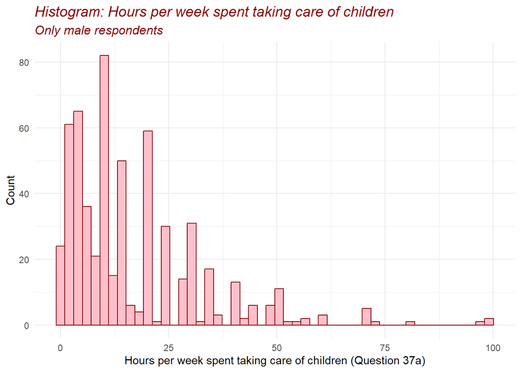

```r
ggplot(data = Dataset_CP_m, aes(x = Q37a_HoursWeekChildren)) +
  geom_histogram(bins = 50, color = "darkred", fill = "pink") +
  theme_minimal()+
  labs(title = "Histogram: Hours per week spent taking care of children", subtitle = "Only male respondents")+
  xlab("Hours per week spent taking care of children (Question 37a)") +
  ylab("Count") +
  theme(plot.title = element_text(color = "darkred", size = 14, face = "italic"), plot.subtitle = element_text(color = "darkred", size = 12, face = "italic"))
```

Creating graphs with *ggplot* requires a specific structure in the code, which is built on layers (in this example, we use five layers, but we can add many more, depending on the type of graph that we want to create and how many details we want to include and define - for instance adding a legend, etc).

- In the first layer we call the *ggplot* function and we specify the *data* that we will use in the graph as well as the variable(s) that we want to plot inside *aes*.
- We then add a second layer specifying the type of graph we want to use with this data (here we use *geom_histogram* for a histogram, but we could specify *geom_point* for a scatterplot, or *geom_line* for drawing a line, etc) together with some details about the graph (in this case, the number of bins, the color of the outline of the bars as well as the filling color). The number of bins refers to the number of intervals on which the data is split. Depending on the data, different number of bins are more or less appropriate. In this case, we indicate that we want our data to be split in 50 intervals. You could indicate a different number or you could also leave the *bins* option out of the code and let R select it (R will give a warning (not error) about the number of bins which has been selected). Each type of graph has its own set of options that can be set, use the help function to learn more about them.
- Next, we call a pre-defined layout of the graph called *theme_minimal*. There are many pre-defined layouts and you are free to choose whichever you like the most, or even create your own layout (which is partially what we do with the last layer).
- In the fourth layer we use *labs* in order to define the title of the graph, we add a subtitle and we specify the name of the axes. There are more options that you can define within *labs*, use *help(labs)* to find out what these are.
- Finally, we edit the appearance of the title and subtitle using *theme* and introducing the elements *plot.title = element_text()* and *plot.subtitle = element_text()*, where we specify their *color*, *size* and *face*. With that, we are able to change the format of the title and subtitle, however, it is not always necessary. If you want to find out more options that you can specify within theme, you can use *help(“theme”)* or search in Google.

## c.) Summary Table

To summarize, we can build a table showing the mean and the standard deviation for the variable **Q37a_HoursWeekChildren** for the two groups, separately. To do so, we use two features:

First, in the menu bar of your Quarto document (on top), we click on “Table” and then select “Insert Table”. A new window will appear and ask us the number of rows and columns our table should include. Once the table has been created, we can fill in its cells with whatever we wish to present in the table.

Second, we use inline code, which allows us to embed directly into the text the output of an R code (you can find more information about inline coding [here](https://r4ds.hadley.nz/quarto.html)).

A chunk of code, as we have seen so far, is separated from the text of our Quarto document and does not allow us to build a readable text combining words with output from R codes which in one linear sentence. So, if we want to say:  
The number of male respondents in our dataset is equal to

```r
Dataset_CP_m %>% summarize(n = n())
```

```
# A tibble: 1 × 1
      n
  <int>
1  1723
```

We can clearly see that this is not ideal when using a chunk of code.  
To better integrate this into our text we can use inline code. To do so, in the menu bar of our Quarto document (on top), we click on “</>”, then we type r and add a space and then write the line of code we would like to execute in order to include its output into the text. In our previous example, this could be done by writing as an inline code “r Dataset_CP_m %>% summarize(n = n())”, as follows:  
The number of male respondents in our dataset is equal to 1723

This could be useful, for instance, if we wish to present some properties of the data without us manually copy-pasting the numbers from the console to the text. At the same time, we can use this to populate our table, as we indeed do below.

**Tip**

In a Quarto document, you can run the code which is included in a chunk of code with the green play button. This allows you to execute and visualize the output of that specific command. Unfortunately, inline codes do not have the same option. Inline codes will be executed only when the Quarto document is rendered. This means that you cannot directly see the result of inline codes before you render your Quarto document nor you can verify if that code is correct (and if it is not, the rendering will not work).

To overcome this issue, you can copy-paste the code of your inline code into the Console and run it from there. This will allow you to verify if the code is correct and what is the output.

We have created here a table summarizing some of the descriptive statistics for the male respondents in our dataset. Take a look at this table:

|  | Male |
| --- | --- |
| N_total | 1723 |
| N_missing | 1148 |
| N_valid | 575 |
| Mean | 16.8591304 |
| Std. Deviation | 15.5294252 |

Notice how we use the pipe operator on the dataset to compute the descriptive statistics with the *summarize* function and

- the *n* function to calculate the total number of observations;
- the *is.na* function to calculate the number of observations with missing values;
- the *!* operator combined with the *is.na* function to calculate the opposite of the number of observations with missing values, i.e., the number of observations with valid values;
- the *mean* function to calculate the mean, with the *na.rm* option set to TRUE to tell R that there are missing values and it should compute the mean without considering the missing values;
- the *sd* function to calculate the standard deviation, with the *na.rm* option set to TRUE to tell R that there are missing values and it should compute the standard deviation without considering the missing values.

## d.) Clearing the Environment

Since we will no longer use nor need the subsets of data that we created in the previous parts of the assignment, let’s remove all the objects from the Global Environment apart from the original dataset. We can do so using the *rm* function combined with the *setdiff* function, which tells the *rm* function to remove all the elements in the Global Environment (which are listed using the *ls* function) apart from “Dataset_CP”:

```r
#rm(list = setdiff(ls(), "Dataset_CP"))
```

## e.) Creating a new Dataset with a new Variable

Create a new variable showing the number of hours of caregiving for children/grandchildren per day, based on **Q37a_HoursWeekChildren**. Provide a meaningful name for your new variable.

```r
Dataset_CP1_modified <- Dataset_CP %>%
  mutate(Q37a_HoursWeekChildren_daily = Q37a_HoursWeekChildren / 7)
```

Notice how we use the pipe operator in combination with the *mutate* function on the original dataset to create the new variable. The *mutate* function is very useful as it allows us to create new variable and modify our dataset.

Notice also how we use the assignment operator, *<-*, to save the modified dataset to a new object called **Dataset_CP1_modified**. It is good practice to never modify your raw / original dataset. If you need to modify your data (change labels of variables, delete cases, compute new variables etc.) do it in a new dataset. In this way, if you do a mistake, you can always go back to the original data. This is why, in this case, we are creating *Dataset_CP1_modified* to change variable or create new ones.

For completenes of information, it is useful for you to know that by saving the modified dataset directly on the original dataset (and not on a new object), we would have added the new variable to the original loaded dataset. We could have done so with the following code:

Dataset_CP <- Dataset_CP %>%  
mutate(Q37a_HoursWeekChildren_daily = Q37a_HoursWeekChildren / 7)

As indicated above, this would have however overwritten the original loaded dataset and it is good practice to never adjust the raw datafile.

# OLS

## **General Description and notation of a Linear Regression**

In R, the **`set.seed()`** function is used to set the random number generator’s seed. Random number generators in computer programming are not truly random; they are pseudo-random, meaning they generate sequences of numbers that appear random but are actually determined by an initial starting point called a seed. If you set the seed to a specific value, you can reproduce the same sequence of random numbers every time you run your program. This is important in many data analysis and simulation tasks, as it allows for the results to be reproducible.

**Note**: we will use the **`cat()`** function today. The **`cat()`** function is used for printing or concatenating objects to the console. It is primarily used to display text, numbers, or other R objects on the screen or to write them to a file. The name “cat” stands for “concatenate” or “concatenation,” as the function can be used to combine and display multiple objects.

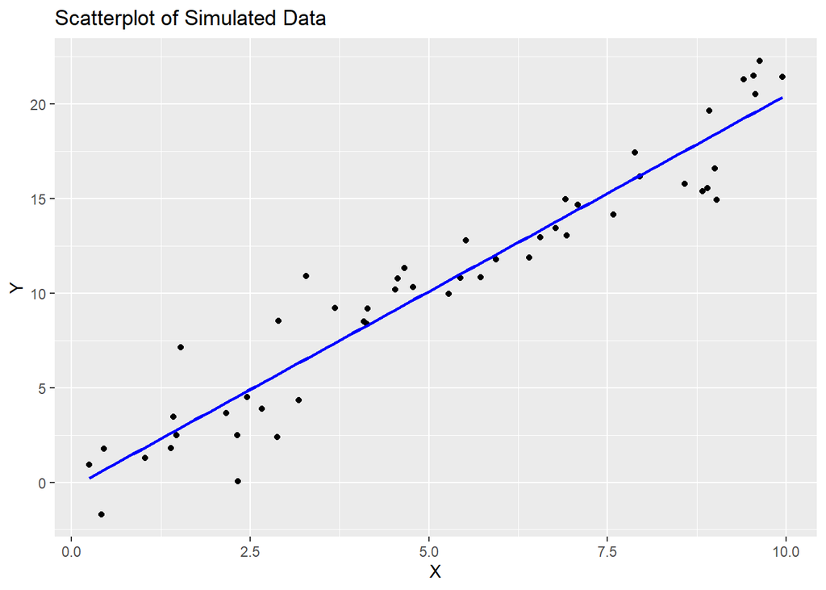

```r
# Generate example data
set.seed(123)
n <- 50
x <- runif(n, 0, 10)
y <- 2 * x + rnorm(n, 0, 2)

# Create a scatterplot
ggplot(data = data.frame(x, y), aes(x = x, y = y)) +
  geom_point() +
  geom_smooth(method = "lm", se = FALSE, color = "blue") +
  labs(title = "Scatterplot of Simulated Data",
       x = "X", y = "Y")
```

## The notation

```r
#
cat("Linear Regression Notation:\n")
```

```
Linear Regression Notation:
```

```r
cat("Y = β₀ + β₁*X + ε\n")
```

```
Y = β₀ + β₁*X + ε
```

```r
cat("Y: Dependent variable (response)\n")
```

```
Y: Dependent variable (response)
```

```r
cat("X: Independent variable (predictor)\n")
```

```
X: Independent variable (predictor)
```

```r
cat("β₀: Intercept (constant)\n")
```

```
β₀: Intercept (constant)
```

```r
cat("β₁: Coefficient for X (slope)\n")
```

```
β₁: Coefficient for X (slope)
```

```r
cat("ε: Error (residuals)\n")
```

```
ε: Error (residuals)
```

## **Running and reporting OLS Regression**

In R, the **`lm()`** function is used to fit linear regression models. Linear regression is a statistical method used to model the relationship between a dependent variable and one or more independent variables by finding the best-fitting linear equation. The **`lm()`** function is a fundamental tool for performing linear regression analysis in R.

Here’s how to use the **`lm()`** function in R:

*model <- lm(dependent_variable ~ independent_variable1 + independent_variable2, data = your_data_frame)*

Let’s break down the components of this function:

1. **`dependent_variable`**: This is the variable you want to predict or model. It is the response variable, typically numeric.
2. **`independent_variable1`**, **`independent_variable2`**, …: These are the variables that you believe are related to the dependent variable. They are the predictor variables, which can be numeric or categorical.
3. **`data`**: This argument specifies the data frame in which the variables are located. You should specify the name of your data frame here.

The **`lm()`** function returns a linear regression model object, which contains information about the estimated coefficients and other statistical details of the model.

After fitting the model, you can access various information and summaries, such as:

- **`summary(model)`**: This function provides a detailed summary of the regression model, including coefficients, standard errors, t-values, p-values, R-squared, and more.
- **`coef(model)`**: This function returns the estimated coefficients of the model.
- **`predict(model, newdata)`**: You can use this function to make predictions with the model, where **`newdata`** is a data frame containing the values of the independent variables for which you want to make predictions.

```r
# Fit an OLS regression model
model <- lm(y ~ x)

# Display the model summary
summary(model)
```

```
Call:
lm(formula = y ~ x)

Residuals:
    Min      1Q  Median      3Q     Max
-4.5116 -1.1157 -0.1313  1.0985  4.3723

Coefficients:
            Estimate Std. Error t value Pr(>|t|)
(Intercept)  -0.2847     0.5442  -0.523    0.603
x             2.0764     0.0913  22.743   <2e-16 ***
---
Signif. codes:  0 '***' 0.001 '**' 0.01 '*' 0.05 '.' 0.1 ' ' 1

Residual standard error: 1.881 on 48 degrees of freedom
Multiple R-squared:  0.9151,    Adjusted R-squared:  0.9133
F-statistic: 517.2 on 1 and 48 DF,  p-value: < 2.2e-16
```

## **Interpretation of Coefficients**

For numeric independent variables, a positive coefficient means that an increase in the independent variable is associated with an increase in the dependent variable, and a negative coefficient means the opposite.

For categorical independent variables (e.g., dummies for categories), the coefficients represent the difference in the dependent variable for that category compared to the reference category.

```r
# Extract and interpret coefficients
cat("Intercept (β₀): ", coef(model)[1], "\n")
```

```
Intercept (β₀):  -0.2847054
```

```r
cat("Coefficient for X (β₁): ", coef(model)[2], "\n")
```

```
Coefficient for X (β₁):  2.076349
```

## **Goodness of Fit (F-Statistics and Adjusted R-squared)**

**Note**: to extract p-value of F-statistic you have to use the function pf() that gives the area, for the F distribution, to the left of the value x for two given degrees of freedom, df1 and df2.

```r
# Adjusted R-squared
cat("Adjusted R-squared: ", summary(model)$adj.r.squared, "\n")
```

```
Adjusted R-squared:  0.9133112
```

```r
# Print the F-statistic and p-value
cat("F-statistic:", summary(model)$fstatistic[1], "\n")
```

```
F-statistic: 517.2401
```

```r
p_val = pf(summary(model)$fstatistic[1],summary(model)$fstatistic[2],summary(model)$fstatistic[3],lower.tail=FALSE)
cat("p-value:", p_val, "\n")
```

```
p-value: 2.364413e-27
```

## **Assumption Diagnostics**

```r
#For multiple independent variables
# cor_matrix <- cor(data_frame[c("dep_var", "ind_var1", "ind_var2", "ind_var3")])
#print(cor_matrix)
```

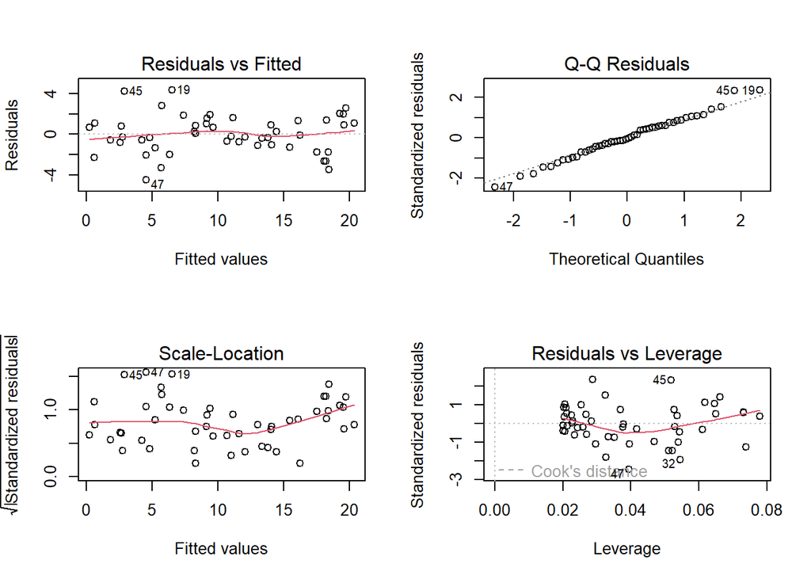

```r
# Check OLS assumptions
par(mfrow = c(2, 2))
plot(model)
```

**Warning**

The next portion is where you can now answer and edit.

# Assignment Questions:

## Data Management and Descriptive Statistics

### a.) Descriptive Statistics of Female Respondents

In this section, subset the original dataset for female respondents and just like what we did for the Male respondents, do the same with the female respondents. When plotting the histogram, use different colors for the graph as well as for the title and subtitle. To find which options you can use, search in Google.

**Note**

Do the descriptive statistics, frequency table, histogram and summary table.

**[ANSWER]**

Descriptive Statistics

```r
psych::describe(Dataset_CP_f$Q37a_HoursWeekChildren)
```

```
   vars    n  mean    sd median trimmed   mad min max range skew kurtosis   se
X1    1 1026 30.14 31.35     20   24.31 19.27   1 168   167 2.25     6.17 0.98
```

```r
Dataset_CP_f %>% summarize(n = n())
```

```
# A tibble: 1 × 1
      n
  <int>
1  2313
```

```r
Dataset_CP_f %>% summarize(n_na = sum(is.na(Q37a_HoursWeekChildren)))
```

```
# A tibble: 1 × 1
   n_na
  <int>
1  1287
```

Frequency Table

```r
epiDisplay::tab1(Dataset_CP_f$Q37a_HoursWeekChildren, cum.percent = TRUE, graph = FALSE)
```

```
Dataset_CP_f$Q37a_HoursWeekChildren :
        Frequency   %(NA+) cum.%(NA+)   %(NA-) cum.%(NA-)
1              16      0.7        0.7      1.6        1.6
2              27      1.2        1.9      2.6        4.2
3              36      1.6        3.4      3.5        7.7
4              36      1.6        5.0      3.5       11.2
5              41      1.8        6.7      4.0       15.2
6              19      0.8        7.6      1.9       17.1
7              39      1.7        9.3      3.8       20.9
8              28      1.2       10.5      2.7       23.6
9               2      0.1       10.5      0.2       23.8
10            105      4.5       15.1     10.2       34.0
12             19      0.8       15.9      1.9       35.9
14             27      1.2       17.1      2.6       38.5
15             49      2.1       19.2      4.8       43.3
```

[output cut: 53 more lines]

Histogram

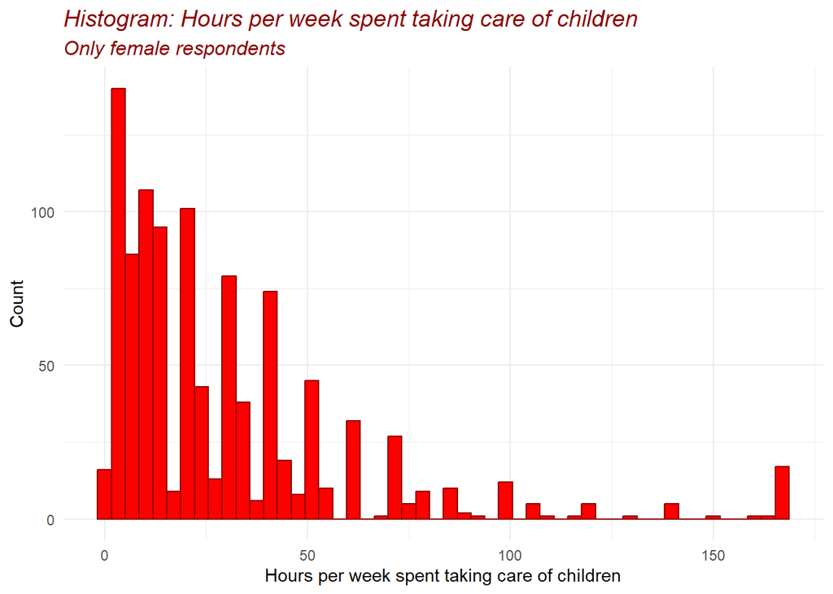

```r
ggplot(data = Dataset_CP_f, aes(x = Q37a_HoursWeekChildren)) +
  geom_histogram(bins = 50, color = "darkred", fill = "red") +
  theme_minimal()+
  labs(title = "Histogram: Hours per week spent taking care of children", subtitle = "Only female respondents")+
  xlab("Hours per week spent taking care of children") +
  ylab("Count") +
  theme(plot.title = element_text(color = "darkred", size = 14, face = "italic"), plot.subtitle = element_text(color = "darkred", size = 12, face = "italic"))
```

### b.)

Study the Frequency Tables and the Histograms we obtained. Do you notice anything strange, with respect to the valid values and the missing values?

**[ANSWER]**

There are more NA’s than valid values (55.6% NA).

### c.) Create a new Dataset and New Variable

**Tip**

Only keep the original data file in your Environment then, create a new dataset with a new variable. It is up to you to name the new dataset and new variable.

Create a new variable showing the number of hours of caregiving for children per year. Provide a meaningful name for your new variable.

**[ANSWER]**

```r
# create new variable for hours caregiving for child per year without NA
Dataset_CP1f_modified <- Dataset_CP %>%
  mutate(Q37a_HoursWeekChildren_daily = Q37a_HoursWeekChildren * 52)
```

### d.)

Save the modified dataset into a new file with the *save* function, save also this Quarto file and render it into its output file (by point and clicking directly), with an eye to the signing off process with the assistant. Finally, before starting the next assignment, remove all the objects stored in the memory with the *rm* function (NOTE: the same applies to all other assignments!)

To save our R objects in the computer, we can use the *save* function. We first need to specify which object we want to save and then, using the option *file =* we specify the name we wish to provide to the file that we are saving in our computer. Unless you provide a specific path, this file will be saved in our working directory.

```r
# Let's save the modified dataset into a new file
save(Dataset_CP1f_modified, file = "dataset_careGiving_peryear.RData")

# Let's clear the memory
#rm(list=ls())
```

**[ANSWER]**

## OLS Regression

Now, it is time to work with real-world data. We will use **`wage.xlsx`** data that is made up of the `wage rate per hour` of US workers, their `education in years` , `exper in months` and `tenure in months` .

**Note**: you need to use your knowledge acquired in the previous practical to manipulate the data before running regression models.

Since we are using Excel data, we need to load the dataset. You will need to install the readxl package if you cannot find it in the Packages. Make sure that the Excel file is in your Working Directory.

```r
if(!("readxl" %in% installed.packages()[,"Package"])) install.packages("readxl")
library(readxl)

data_wage <- read_excel("wage.xlsx")
# View(wage) #opens and views the wage dataset
```

### a.) Descriptive Statistics

Provide descriptive statistics and visualize the distribution of `wage` and `education`. Reflect on your observation and decide whether to transform these two variables.

**[ANSWER]**

**Wage**

```r
psych::describe(data_wage$wage)
```

```
   vars   n mean   sd median trimmed  mad  min   max range skew kurtosis   se
X1    1 526  5.9 3.69   4.65    5.24 2.37 0.53 24.98 24.45    2     4.94 0.16
```

```r
epiDisplay::tab1(data_wage$wage, cum.percent = TRUE, graph = FALSE)
```

```
data_wage$wage :
        Frequency Percent Cum. percent
0.53            1     0.2          0.2
1.43            1     0.2          0.4
1.5             2     0.4          0.8
1.63            1     0.2          1.0
1.67            1     0.2          1.1
1.75            1     0.2          1.3
1.96            1     0.2          1.5
2               4     0.8          2.3
2.14            1     0.2          2.5
2.17            1     0.2          2.7
2.23            1     0.2          2.9
2.25            1     0.2          3.0
2.27            1     0.2          3.2
2.3             1     0.2          3.4
2.31            1     0.2          3.6
2.38            1     0.2          3.8
2.5             1     0.2          4.0
2.53            1     0.2          4.2
2.54            1     0.2          4.4
2.6             1     0.2          4.6
2.65            1     0.2          4.8
2.7             1     0.2          4.9
2.75            1     0.2          5.1
2.83            1     0.2          5.3
2.87            1     0.2          5.5
2.88            1     0.2          5.7
2.89            2     0.4          6.1
2.9            16     3.0          9.1
2.91            4     0.8          9.9
2.92            5     1.0         10.8
2.93            1     0.2         11.0
2.95            3     0.6         11.6
3              34     6.5         18.1
3.05            3     0.6         18.6
3.06            1     0.2         18.8
3.08            1     0.2         19.0
3.1             4     0.8         19.8
3.13            3     0.6         20.3
```

[output cut: 189 more lines]

```
17.33           1     0.2         97.3
17.5            1     0.2         97.5
17.71           1     0.2         97.7
18              1     0.2         97.9
18.16           2     0.4         98.3
18.18           1     0.2         98.5
18.89           1     0.2         98.7
19.98           1     0.2         98.9
20              1     0.2         99.0
21.63           1     0.2         99.2
21.86           1     0.2         99.4
22.2            1     0.2         99.6
22.86           1     0.2         99.8
24.98           1     0.2        100.0
  Total       526   100.0        100.0
```

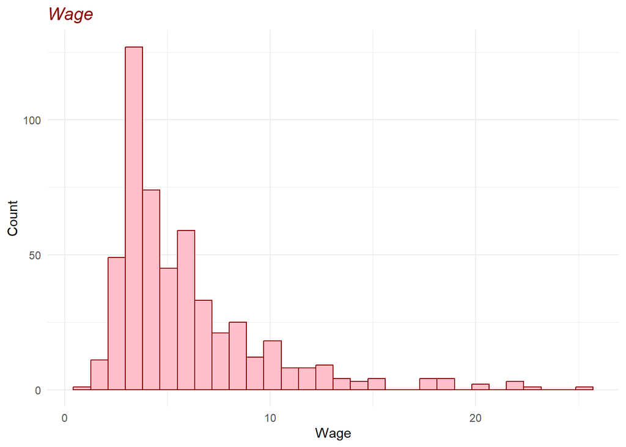

```r
ggplot(data = data_wage, aes(x = wage)) +
  geom_histogram(color = "darkred", fill = "pink") +
  theme_minimal()+
  labs(title = "Wage")+
  xlab("Wage") +
  ylab("Count") +
  theme(plot.title = element_text(color = "darkred", size = 14, face = "italic"), plot.subtitle = element_text(color = "darkred", size = 12, face = "italic"))
```

**Education**

```r
psych::describe(data_wage$educ)
```

```
   vars   n  mean   sd median trimmed  mad min max range  skew kurtosis   se
X1    1 526 12.56 2.77     12   12.69 1.48   0  18    18 -0.62     1.87 0.12
```

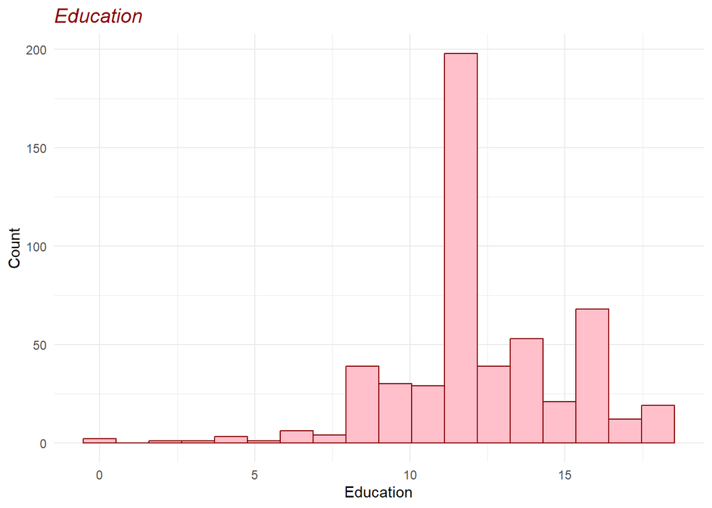

```r
ggplot(data = data_wage, aes(x = educ)) +
  geom_histogram(bins = 18, color = "darkred", fill = "pink") +
  theme_minimal()+
  labs(title = "Education")+
  xlab("Education") +
  ylab("Count") +
  theme(plot.title = element_text(color = "darkred", size = 14, face = "italic"), plot.subtitle = element_text(color = "darkred", size = 12, face = "italic"))
```

### b.) Bivariate Linear Regression

Run OLS and report the result. Interpret the sign, significance, and magnitude of effects of `education` on `wage`.

*TRANSFORM THE VARIABLE!!!*

**[ANSWER]**

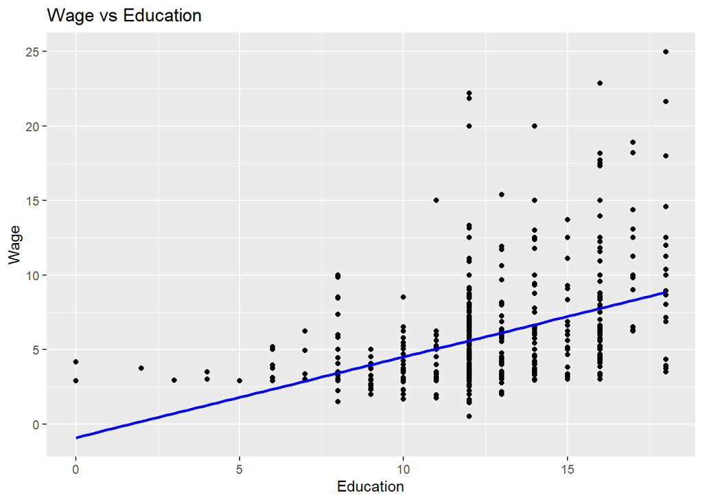

```r
ggplot(data = data_wage, aes(x = educ, y = wage)) +
  geom_point() +
  geom_smooth(method = "lm", se = FALSE, color = "blue") +
  labs(title = "Wage vs Education",
       x = "Education", y = "Wage")
```

```r
# Fit an OLS regression model
model_wage <- lm(wage ~ educ, data = data_wage)

# Display the model summary
summary(model_wage)
```

```
Call:
lm(formula = wage ~ educ, data = data_wage)

Residuals:
    Min      1Q  Median      3Q     Max
-5.3396 -2.1501 -0.9674  1.1921 16.6085

Coefficients:
            Estimate Std. Error t value Pr(>|t|)
(Intercept) -0.90485    0.68497  -1.321    0.187
educ         0.54136    0.05325  10.167   <2e-16 ***
---
Signif. codes:  0 '***' 0.001 '**' 0.01 '*' 0.05 '.' 0.1 ' ' 1

Residual standard error: 3.378 on 524 degrees of freedom
Multiple R-squared:  0.1648,    Adjusted R-squared:  0.1632
F-statistic: 103.4 on 1 and 524 DF,  p-value: < 2.2e-16
```

```r
# Extract and interpret coefficients
cat("Intercept (β₀): ", coef(model_wage)[1], "\n")
```

```
Intercept (β₀):  -0.9048517
```

```r
cat("Coefficient for X (β₁): ", coef(model_wage)[2], "\n")
```

```
Coefficient for X (β₁):  0.5413593
```

While a positive coefficient means that there is a positive relationship between the two variables, the low R squared value may suggest that line fit is not ideal. Hence, the relationship and the magnitude of the relationship is not conclusive.

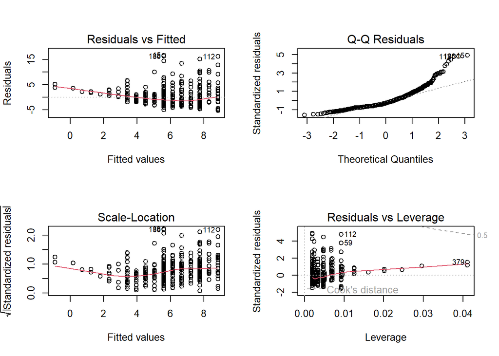

```r
par(mfrow = c(2, 2))
plot(model_wage)
```

### c.) Assumption Diagnostics

Check whether your model violates OLS assumption. Reflect on your observation and discuss the potential causes of problems.

**[ANSWER]**

One potential cause for violation of OLS is that the relationship between the variables is not linear. We note that the R-squared value is very low (0.165). It follows that the independent variable does not necessarily correlate to the variation of the dependent variable. Furthermore, the presence of significant numbers of outliers means that the residuals may not be normally distributed.

### d.) Multivariate Linear Regression

Run new OLS models, including `exper` and `tenure` as new control variables. Check for OLS assumptions. Compare the goodness of fit of your model with the one without these two controls. Reflect on your observation and discuss why the goodness of fit increased or decreased.

**[ANSWER]**

```r
# Fit an OLS regression model
multi_model_wage <- lm(wage ~ educ + exper + tenure, data = data_wage)

# Display the model summary
summary(multi_model_wage)
```

```
Call:
lm(formula = wage ~ educ + exper + tenure, data = data_wage)

Residuals:
    Min      1Q  Median      3Q     Max
-7.6068 -1.7747 -0.6279  1.1969 14.6536

Coefficients:
            Estimate Std. Error t value Pr(>|t|)
(Intercept) -2.87273    0.72896  -3.941 9.22e-05 ***
educ         0.59897    0.05128  11.679  < 2e-16 ***
exper        0.02234    0.01206   1.853   0.0645 .
tenure       0.16927    0.02164   7.820 2.93e-14 ***
---
Signif. codes:  0 '***' 0.001 '**' 0.01 '*' 0.05 '.' 0.1 ' ' 1

Residual standard error: 3.084 on 522 degrees of freedom
Multiple R-squared:  0.3064,    Adjusted R-squared:  0.3024
F-statistic: 76.87 on 3 and 522 DF,  p-value: < 2.2e-16
```

```r
# Extract and interpret coefficients
cat("Intercept (β₀): ", coef(multi_model_wage)[1], "\n")
```

```
Intercept (β₀):  -2.872735
```

```r
cat("Coefficient for educ (β1): ", coef(multi_model_wage)[2], "\n")
```

```
Coefficient for educ (β1):  0.5989651
```

```r
cat("Coefficient for exper (β2): ", coef(multi_model_wage)[3], "\n")
```

```
Coefficient for exper (β2):  0.02233952
```

```r
cat("Coefficient for tenure (β3): ", coef(multi_model_wage)[4], "\n")
```

```
Coefficient for tenure (β3):  0.1692687
```

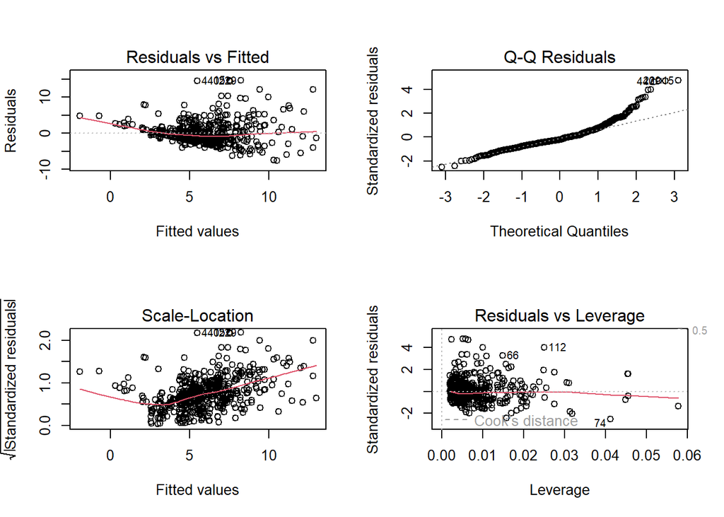

```r
par(mfrow = c(2, 2))
plot(multi_model_wage)
```

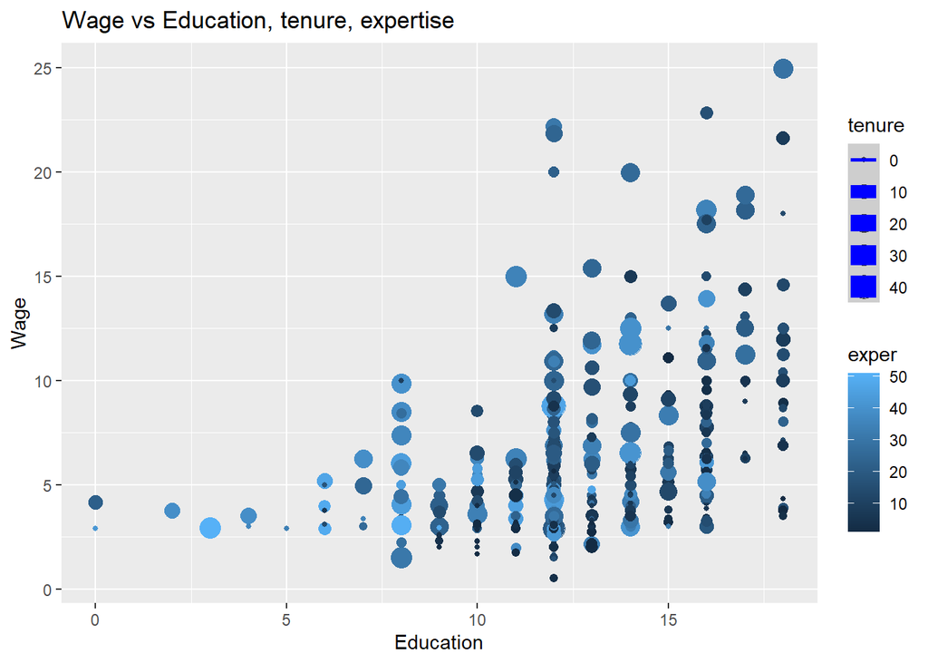

```r
ggplot(data = data_wage, aes(x = educ, y = wage, color = exper, size = tenure)) +
  geom_point() +
  geom_smooth(method = "lm", formula = y ~ educ + exper + tenure, color = "blue") +
  labs(title = "Wage vs Education, tenure, expertise",
       x = "Education", y = "Wage")
```

While the Rsquared value increased, we can clearly see from the plots that the OLS assumptions are violated here more than in the single linear regression. That is, we can see clear funnel shapes, non-random scattering, etc. This may suggest that the adding more predictors made the model more complex which may lead to overfitting.